# Prediction Asignment Writeup

Daniel David Pamplona

November 13, 2018

# Introduction

Accelerometers provide quantitative information on the movement of participants wearing them. It is particularly useful not only in measuring how much of an activity you do, but also how well you do it. In this project, the goal is to use data from accelerometers on the belt, forearm, arm, and dumbell of 6 participants to predict the type of exercise performed. More information can be found from the website here: http://web.archive.org/web/20161224072740/http:/groupware.les.inf.puc-rio.br/har

# Overview of Analyses

This write up is generally divided into 5 parts, namely:

- **Getting Data** - extracting data from a specified source
- **Cleaning Data** - removal of unecessary variables to reduce model complexity and computing time.
- **Cross Validation** - subsetting the data to create a pseudo train and psuedo validation data set to estimate test error.
- **Model Selection** - application of machine learning algorithims to the data. Each model is evaluated by its predictive accuracy to the pseudo validaton set.
- **Final Conclusions** - interpretation of final model and general conlusions.

# Getting Data

The data for this project came from **Groupware@LES**, also called the *Human Activity Recognition* **HAR** data set. More information about the data set is found here:http://web.archive.org/web/20161224072740/http:/groupware.les.inf.puc-rio.br/har

```r
train <- read.csv("C:/Users/David/Desktop/pml-training.csv")
test <- read.csv("C:/Users/David/Desktop/pml-testing.csv")
```

#### Some Exploratory Techniques

```r
library(ggplot2)
library(gridExtra)
class(train$classe)
```

```
## [1] "factor"
```

```r
table(train$classe)
```

```
##
##    A    B    C    D    E
## 5580 3797 3422 3216 3607
```

[figure not shown]

```r
pb <- ggplot(train, aes(classe, pitch_belt))
pb <- pb + geom_boxplot() + ggtitle("Roll Belt")
yb <- ggplot(train, aes(classe, yaw_belt))
yb <- yb + geom_boxplot() + ggtitle("Yaw Belt")
rb <- ggplot(train, aes(classe, roll_belt))
rb <- rb + geom_boxplot() + ggtitle("Roll Belt")
ta.b <- ggplot(train, aes(classe, total_accel_belt))
ta.b <- ta.b + geom_boxplot() + ggtitle("Total Accel Belt")
grid.arrange(pb,yb,rb,ta.b,nrow=2,ncol=2)
```

# Cleaning Data

It can be observed that several variables (columns) in the data have mostly `NA` or `missing` values. These variables were removed as they do not contribute to model efficiency and prediction. A straightforward criteria was used, if the column has at least 90% `NA` or `missing` values that column is discarded. Also, the first seven columns were removed since these variables are not accelerometer measurements. The columns removed in the train data set are the same columns removed in the test set to fascilitate scalability.

```r
str(train)
```

```
## 'data.frame':    19622 obs. of  160 variables:
##  $ X                       : int  1 2 3 4 5 6 7 8 9 10 ...
##  $ user_name               : Factor w/ 6 levels "adelmo","carlitos",..: 2 2 2 2 2 2 2 2 2 2 ...
##  $ raw_timestamp_part_1    : int  1323084231 1323084231 1323084231 1323084232 1323084232 1323084232 1323084232 1323084232 1323084232 1323084232 ...
##  $ raw_timestamp_part_2    : int  788290 808298 820366 120339 196328 304277 368296 440390 484323 484434 ...
##  $ cvtd_timestamp          : Factor w/ 20 levels "02/12/2011 13:32",..: 9 9 9 9 9 9 9 9 9 9 ...
##  $ new_window              : Factor w/ 2 levels "no","yes": 1 1 1 1 1 1 1 1 1 1 ...
##  $ num_window              : int  11 11 11 12 12 12 12 12 12 12 ...
##  $ roll_belt               : num  1.41 1.41 1.42 1.48 1.48 1.45 1.42 1.42 1.43 1.45 ...
##  $ pitch_belt              : num  8.07 8.07 8.07 8.05 8.07 8.06 8.09 8.13 8.16 8.17 ...
##  $ yaw_belt                : num  -94.4 -94.4 -94.4 -94.4 -94.4 -94.4 -94.4 -94.4 -94.4 -94.4 ...
##  $ total_accel_belt        : int  3 3 3 3 3 3 3 3 3 3 ...
##  $ kurtosis_roll_belt      : Factor w/ 397 levels "","-0.016850",..: 1 1 1 1 1 1 1 1 1 1 ...
##  $ kurtosis_picth_belt     : Factor w/ 317 levels "","-0.021887",..: 1 1 1 1 1 1 1 1 1 1 ...
##  $ kurtosis_yaw_belt       : Factor w/ 2 levels "","#DIV/0!": 1 1 1 1 1 1 1 1 1 1 ...
```

[output cut: 86 more lines]

```r
i.remcol <- which(colSums(is.na(train) |train=="")>0.9*dim(train)[1])
train.f <- train[,-i.remcol]
train.f <- train.f[,-c(1:7)]    # Since the first 7 columns are not useful for prediction

# Cleaning Test Data (Using the removed variables in train)
test.f <- test[,-i.remcol]
test.f <- test.f[,-c(1:7)]
```

# Cross-Validation

The train data set is further subdived into two parts, a pseudo train data (`train.f1`) and a pseudo test data (`train.f2`) to estimate the test error. The proportion for each partition is 70 and 30 respectively.

```r
library(caret)
library(gbm)
inTrain = createDataPartition(train$classe, p = 0.7, list=FALSE)
train.f1 = train.f[ inTrain,]
train.f2 = train.f[-inTrain,]
```

# Model Selection

In predicting the type of exercise `classe`, we try out 2 different machine learning algorithms: **Random Forest** and **Boosting**. We also include a third model using the stacked version of the two. The models are evaluated based on their predictive accuracy on the pseudo test data `train.f2`.

```r
library(caret)
library(gbm)
set.seed(62433)

# Random Forest
mod_rf <- train(classe ~ ., data = train.f1, method = "rf")
pred_rf <- predict(mod_rf, train.f2)
confusionMatrix(pred_rf,train.f2$classe)$table
```

```
##           Reference
## Prediction    A    B    C    D    E
##          A 1672   10    0    0    1
##          B    1 1127    3    0    1
##          C    1    2 1019    8    0
##          D    0    0    4  954    1
##          E    0    0    0    2 1079
```

```r
confusionMatrix(pred_rf,train.f2$classe)$overall[1]
```

```
##  Accuracy
## 0.9942226
```

```r
# Boosting
mod_gbm <- train(classe ~ ., data = train.f1, method = "gbm", verbose=FALSE)
pred_gbm <- predict(mod_gbm, train.f2)
confusionMatrix(pred_gbm,train.f2$classe)$table
```

```
##           Reference
## Prediction    A    B    C    D    E
##          A 1646   47    0    0    2
##          B   20 1057   33    3   17
##          C    7   33  976   27    7
##          D    1    1   17  925   14
##          E    0    1    0    9 1042
```

```r
confusionMatrix(pred_gbm,train.f2$classe)$overall[1]
```

```
##  Accuracy
## 0.9593883
```

```r
# Stacked predictors
predDF <- data.frame(pred_rf, pred_gbm, classe = train.f2$classe)
mod_comb <- train(classe ~ ., method = "rf", data = predDF)
pred_comb <- predict(mod_comb, train.f2)
confusionMatrix(pred_comb,train.f2$classe)$overall[1]
```

```
##  Accuracy
## 0.9942226
```

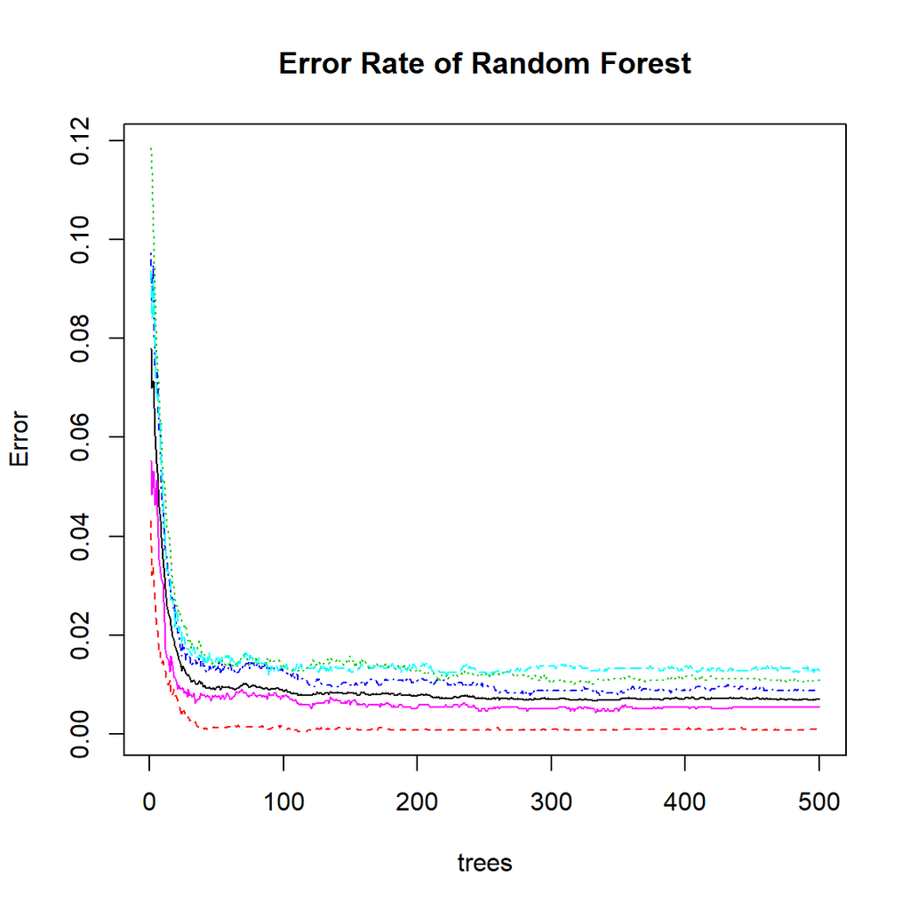

```r
plot(mod_rf$finalModel, main="Error Rate of Random Forest")
```

```r
varImp(mod_rf, pc=10, main="Variable Importance")
```

```
## rf variable importance
##
##   only 20 most important variables shown (out of 52)
##
##                      Overall
## roll_belt             100.00
## pitch_forearm          60.89
## yaw_belt               56.17
## magnet_dumbbell_y      45.56
## pitch_belt             44.49
## magnet_dumbbell_z      44.02
## roll_forearm           41.62
## accel_dumbbell_y       21.98
## accel_forearm_x        17.11
## roll_dumbbell          17.11
## magnet_dumbbell_x      15.44
## magnet_belt_z          14.72
## total_accel_dumbbell   14.48
## magnet_belt_y          13.75
## accel_dumbbell_z       13.65
## magnet_forearm_z       13.64
## accel_belt_z           12.84
## yaw_arm                10.96
## gyros_belt_z           10.88
## magnet_belt_x          10.77
```